# kyadav1_BA_Assignment1

Khushboo Yadav

10/18/2020

## Loading Data and Importing libraries for Online Retail dataset

```r
Online_Retail <- read.csv("~/Desktop/MSBA/Business Analytics/Data/Online_Retail.csv")
View(Online_Retail)

library(dplyr)
library(caret)
library(tidyselect)
library(lubridate)
library(tidyverse)
library(Lahman)

str(Online_Retail) #Analyzing the structure of the dataset
```

```
## 'data.frame':    541909 obs. of  8 variables:
##  $ InvoiceNo  : chr  "536365" "536365" "536365" "536365" ...
##  $ StockCode  : chr  "85123A" "71053" "84406B" "84029G" ...
##  $ Description: chr  "WHITE HANGING HEART T-LIGHT HOLDER" "WHITE METAL LANTERN" "CREAM CUPID HEARTS COAT HANGER" "KNITTED UNION FLAG HOT WATER BOTTLE" ...
##  $ Quantity   : int  6 6 8 6 6 2 6 6 6 32 ...
##  $ InvoiceDate: chr  "12/1/2010 8:26" "12/1/2010 8:26" "12/1/2010 8:26" "12/1/2010 8:26" ...
##  $ UnitPrice  : num  2.55 3.39 2.75 3.39 3.39 7.65 4.25 1.85 1.85 1.69 ...
##  $ CustomerID : int  17850 17850 17850 17850 17850 17850 17850 17850 17850 13047 ...
##  $ Country    : chr  "United Kingdom" "United Kingdom" "United Kingdom" "United Kingdom" ...
```

```r
nrow(Online_Retail) #Determining the row count of the dataset
```

```
## [1] 541909
```

## 1.Show the breakdown of the number of transactions by countries i.e. how many transactions are in the dataset for each country (consider all records including cancelled transactions). Show this in total number and also in percentage. Show only countries accounting for more than 1% of the total transactions. (5 marks)

```r
#Breakdown of the no. of transactions  in numbers and in percentage by Countries

TransactByCountry<-Online_Retail %>%
  group_by( Country ) %>%
  summarise( Percentage = 100 * (n() / nrow( Online_Retail ) ),Number_of_Transactions=n()  ) %>%

#Printing the complete results
print(TransactByCountry)
```

```
## # A tibble: 38 x 3
##    Country         Percentage Number_of_Transactions
##    <chr>                <dbl>                  <int>
##  1 Australia          0.232                     1259
##  2 Austria            0.0740                     401
##  3 Bahrain            0.00351                     19
##  4 Belgium            0.382                     2069
##  5 Brazil             0.00591                     32
##  6 Canada             0.0279                     151
##  7 Channel Islands    0.140                      758
##  8 Cyprus             0.115                      622
##  9 Czech Republic     0.00554                     30
## 10 Denmark            0.0718                     389
## # … with 28 more rows
```

```r
# Output : Countries accounting for for more than 1 percentage

filter(TransactByCountry,TransactByCountry$Percentage>=1)
```

```
## # A tibble: 4 x 3
##   Country        Percentage Number_of_Transactions
##   <chr>               <dbl>                  <int>
## 1 EIRE                 1.51                   8196
## 2 France               1.58                   8557
## 3 Germany              1.75                   9495
## 4 United Kingdom      91.4                  495478
```

## 2.Create a new variable ‘TransactionValue’ that is the product of the exising ‘Quantity’ and ‘UnitPrice’ variables. Add this variable to the dataframe. (5 marks)

```r
#TransactionValue = Quantity*UnitPrice
TransactionValue<-Online_Retail$Quantity*Online_Retail$UnitPrice

#Binding TransactionValue in Online Retail Dataframe
Online_Retail<-cbind(Online_Retail,TransactionValue)

#Using str function to validate the new addition in the Online Retail dataframe
str(Online_Retail)
```

```
## 'data.frame':    541909 obs. of  9 variables:
##  $ InvoiceNo       : chr  "536365" "536365" "536365" "536365" ...
##  $ StockCode       : chr  "85123A" "71053" "84406B" "84029G" ...
##  $ Description     : chr  "WHITE HANGING HEART T-LIGHT HOLDER" "WHITE METAL LANTERN" "CREAM CUPID HEARTS COAT HANGER" "KNITTED UNION FLAG HOT WATER BOTTLE" ...
##  $ Quantity        : int  6 6 8 6 6 2 6 6 6 32 ...
##  $ InvoiceDate     : chr  "12/1/2010 8:26" "12/1/2010 8:26" "12/1/2010 8:26" "12/1/2010 8:26" ...
##  $ UnitPrice       : num  2.55 3.39 2.75 3.39 3.39 7.65 4.25 1.85 1.85 1.69 ...
##  $ CustomerID      : int  17850 17850 17850 17850 17850 17850 17850 17850 17850 13047 ...
##  $ Country         : chr  "United Kingdom" "United Kingdom" "United Kingdom" "United Kingdom" ...
##  $ TransactionValue: num  15.3 20.3 22 20.3 20.3 ...
```

## 3. Using the newly created variable, TransactionValue, show the breakdown of transaction values by countries i.e. how much money in total has been spent each country. Show this in total sum of transaction values. Show only countries with total transaction exceeding 130,000 British Pound. (10 marks)

```r
# Aggregating the results of Transaction Values based on different countries in the Online Retail Dataframe
Sum_TransactByCountry <- Online_Retail%>%
  group_by(Country)%>%
  summarise(Sum_Transaction_Value=sum(TransactionValue))
# Output:Filtering the results based on the 130000 British Pound
filter(Sum_TransactByCountry,Sum_Transaction_Value>130000)
```

```
## # A tibble: 6 x 2
##   Country        Sum_Transaction_Value
##   <chr>                          <dbl>
## 1 Australia                    137077.
## 2 EIRE                         263277.
## 3 France                       197404.
## 4 Germany                      221698.
## 5 Netherlands                  284662.
## 6 United Kingdom              8187806.
```

## Q4.This is an optional question which carries additional marks (golden questions). In this question, we are dealing with the InvoiceDate variable.

```r
#explicitly instructing R to interpret InvoiceDate as a Date variable
Temp=strptime(Online_Retail$InvoiceDate,format='%m/%d/%Y %H:%M',tz='GMT')
head(Temp)
```

```
## [1] "2010-12-01 08:26:00 GMT" "2010-12-01 08:26:00 GMT"
## [3] "2010-12-01 08:26:00 GMT" "2010-12-01 08:26:00 GMT"
## [5] "2010-12-01 08:26:00 GMT" "2010-12-01 08:26:00 GMT"
```

```r
Online_Retail$New_Invoice_Date <- as.Date(Temp)
#convert dates to days of the week
Online_Retail$Invoice_Day_Week= weekdays(Online_Retail$New_Invoice_Date)
#Taking the hour from Temp
Online_Retail$New_Invoice_Hour = as.numeric(format(Temp, "%H"))
#Taking months from Temp
Online_Retail$New_Invoice_Month = as.numeric(format(Temp, "%m"))
```

## 4.a) Show the percentage of transactions (by numbers) by days of the week (extra 2 marks)

```r
# Aggregating and determining percentage  of Transaction Values by number based on different countries
 Prcntg_N_DOW <- Online_Retail%>%
  group_by(Online_Retail$Invoice_Day_Week)%>%
  summarise(Transaction_DOW = (n()),PercentageTransaction = (n()/nrow(Online_Retail))*100)
# Output:To print the results
print(Prcntg_N_DOW)
```

```
## # A tibble: 6 x 3
##   `Online_Retail$Invoice_Day_Week` Transaction_DOW PercentageTransaction
##   <chr>                                      <int>                 <dbl>
## 1 Friday                                     82193                  15.2
## 2 Monday                                     95111                  17.6
## 3 Sunday                                     64375                  11.9
## 4 Thursday                                  103857                  19.2
## 5 Tuesday                                   101808                  18.8
## 6 Wednesday                                  94565                  17.5
```

## 4.b) Show the percentage of transactions (by transaction volume) by days of the week (extra 1 marks)

```r
# Aggregating and determining percentage  of Transaction Values by volume based on different countries
 Prcntg_V_DOW<- Online_Retail%>%
  group_by(Online_Retail$Invoice_Day_Week)%>%
  summarise(Sum_TransactDOW = (sum(TransactionValue)))
#Calculating the percentage
 Prcntg_V_DOW$PercentageTransaction<- (Prcntg_V_DOW$Sum_TransactDOW/sum(Prcntg_V_DOW$Sum_TransactDOW))*100

# Output:Print the result
 print(Prcntg_V_DOW)
```

```
## # A tibble: 6 x 3
##   `Online_Retail$Invoice_Day_Week` Sum_TransactDOW PercentageTransaction
##   <chr>                                      <dbl>                 <dbl>
## 1 Friday                                  1540611.                 15.8
## 2 Monday                                  1588609.                 16.3
## 3 Sunday                                   805679.                  8.27
## 4 Thursday                                2112519                  21.7
## 5 Tuesday                                 1966183.                 20.2
## 6 Wednesday                               1734147.                 17.8
```

## 4.c) Show the percentage of transactions (by transaction volume) by month of the year (extra 1 marks)

```r
# Aggregating and determining percentage  of Transaction Values by volume based on different countries
Prcntg_MOY <- Online_Retail%>%
  group_by(Online_Retail$New_Invoice_Month)%>%
  summarise(Sum_TransactionValue = (sum(TransactionValue)))
#Calculating the percentage
  Prcntg_MOY$Percentage_TransactionValue<- (Prcntg_MOY$Sum_TransactionValue/sum(Prcntg_MOY$Sum_TransactionValue))*100

 # Output:Print the result
  print(Prcntg_MOY)
```

```
## # A tibble: 12 x 3
##    `Online_Retail$New_Invoice_Mon… Sum_TransactionVal… Percentage_TransactionVa…
##                              <dbl>               <dbl>                     <dbl>
##  1                               1             560000.                      5.74
##  2                               2             498063.                      5.11
##  3                               3             683267.                      7.01
##  4                               4             493207.                      5.06
##  5                               5             723334.                      7.42
##  6                               6             691123.                      7.09
##  7                               7             681300.                      6.99
##  8                               8             682681.                      7.00
##  9                               9            1019688.                     10.5
## 10                              10            1070705.                     11.0
## 11                              11            1461756.                     15.0
## 12                              12            1182625.                     12.1
```

## 4.d) What was the date with the highest number of transactions from Australia? (3 marks)

```r
#Filtering the data based on Country = "Australia"
  Australia_Tran<- filter(Online_Retail,Online_Retail$Country=="Australia")

#Aggregating the transactions from Australia based on Invoice Dates
  Australia_Tran_bydate <- Australia_Tran%>%
                           group_by(Australia_Tran$New_Invoice_Date)%>%
                           summarise(TranCount_Aust = n())
  #Arranging the results in order to see the date with highest number of transactions
  arrange(Australia_Tran_bydate,desc(Australia_Tran_bydate$TranCount_Aust))
```

```
## # A tibble: 49 x 2
##    `Australia_Tran$New_Invoice_Date` TranCount_Aust
##    <date>                                     <int>
##  1 2011-06-15                                   139
##  2 2011-07-19                                   137
##  3 2011-08-18                                    97
##  4 2011-03-03                                    84
##  5 2011-10-05                                    82
##  6 2011-05-17                                    73
##  7 2011-02-15                                    69
##  8 2011-01-06                                    48
##  9 2011-07-14                                    35
## 10 2011-09-16                                    34
## # … with 39 more rows
```

```r
#Output:Print the date with highest number of transactions
 top_n(Australia_Tran_bydate,1)
```

```
## # A tibble: 1 x 2
##   `Australia_Tran$New_Invoice_Date` TranCount_Aust
##   <date>                                     <int>
## 1 2011-06-15                                   139
```

## 4.e) The company needs to shut down the website for two consecutive hours for maintenance. What would be the hour of the day to start this so that the distribution is at minimum for the customers? The responsible IT team is available from 7:00 to 20:00 every day. (3 marks)

```r
#Aggregating the no.of transactionValues by hours
  Tran_byhour <- Online_Retail%>%
    group_by(Online_Retail$New_Invoice_Hour)%>%
              summarise(TranCount = n())
 #Creating a variable with numeric data
  smtrn <-numeric()

  #Using for loop for adding consecutive hours together:-

  for (i in 1:dim(Tran_byhour)[1])
   {
  if (between(Tran_byhour$`Online_Retail$New_Invoice_Hour`[i],6,20))
    {
      #Summation of the row [i] with row[i+1]
      smtrn<- c(smtrn,sum((Tran_byhour$TranCount[i]),(Tran_byhour$TranCount[i+1])))

    }
  }
 #Adding column
  Tran_byhour$NextHour<-Tran_byhour[,2]
  Tran_byhour$NextHour<-c(7:20,NA)

  #Combining the data into a single data frame
  Tran_byhour$ConsecutiveHours_CountTransaction<-smtrn

 #Printing the output
 print(Tran_byhour)
```

```
## # A tibble: 15 x 4
##    `Online_Retail$New_Invoice_H… TranCount NextHour ConsecutiveHours_CountTrans…
##                            <dbl>     <int>    <int>                        <dbl>
##  1                             6        41        7                          424
##  2                             7       383        8                         9292
##  3                             8      8909        9                        43241
##  4                             9     34332       10                        83369
##  5                            10     49037       11                       106711
##  6                            11     57674       12                       136383
##  7                            12     78709       13                       150968
##  8                            13     72259       14                       139730
##  9                            14     67471       15                       144990
## 10                            15     77519       16                       132035
## 11                            16     54516       17                        83025
## 12                            17     28509       18                        36483
## 13                            18      7974       19                        11679
## 14                            19      3705       20                         4576
## 15                            20       871       NA                           NA
```

```r
##Filtering 6 hours , due to unavailability of responsible IT team
Tran_byhour<-filter(Tran_byhour,Tran_byhour$`Online_Retail$New_Invoice_Hour`>6)


  #Output:determining the smallest(sum of transactions for2 consecutive hours) number
top_n(Tran_byhour,-1)
```

```
## # A tibble: 1 x 4
##   `Online_Retail$New_Invoice_H… TranCount NextHour ConsecutiveHours_CountTransa…
##                           <dbl>     <int>    <int>                         <dbl>
## 1                            19      3705       20                          4576
```

Answer: Therefore the we can see the least no. of consecutive transactions are happening in the 19-20 hrs.Hence 19hrs and 20 hrs are best for doing the maintainence.

## 5. Plot the histogram of transaction values from Germany. Use the hist() function to plot. (5 marks)

```r
#Making a subset for Germany Transactions
Germany_TransactionValue<-subset(Online_Retail,Country=='Germany')

#To understand the data frame for a better Histogram
summary(Germany_TransactionValue)
```

```
##   InvoiceNo          StockCode         Description           Quantity
##  Length:9495        Length:9495        Length:9495        Min.   :-288.00
##  Class :character   Class :character   Class :character   1st Qu.:   5.00
##  Mode  :character   Mode  :character   Mode  :character   Median :  10.00
##                                                           Mean   :  12.37
##                                                           3rd Qu.:  12.00
##                                                           Max.   : 600.00
##  InvoiceDate          UnitPrice         CustomerID      Country
##  Length:9495        Min.   :  0.000   Min.   :12426   Length:9495
##  Class :character   1st Qu.:  1.250   1st Qu.:12480   Class :character
##  Mode  :character   Median :  1.950   Median :12592   Mode  :character
##                     Mean   :  3.967   Mean   :12646
##                     3rd Qu.:  3.750   3rd Qu.:12662
##                     Max.   :599.500   Max.   :14335
##  TransactionValue  New_Invoice_Date     Invoice_Day_Week   New_Invoice_Hour
##  Min.   :-599.50   Min.   :2010-12-01   Length:9495        Min.   : 8.00
##  1st Qu.:  11.10   1st Qu.:2011-04-04   Class :character   1st Qu.:10.00
##  Median :  16.60   Median :2011-07-19   Mode  :character   Median :12.00
##  Mean   :  23.35   Mean   :2011-07-03                      Mean   :12.11
##  3rd Qu.:  23.40   3rd Qu.:2011-10-11                      3rd Qu.:14.00
##  Max.   : 876.00   Max.   :2011-12-09                      Max.   :19.00
##  New_Invoice_Month
##  Min.   : 1.00
##  1st Qu.: 5.00
##  Median : 8.00
##  Mean   : 7.29
##  3rd Qu.:10.00
##  Max.   :12.00
```

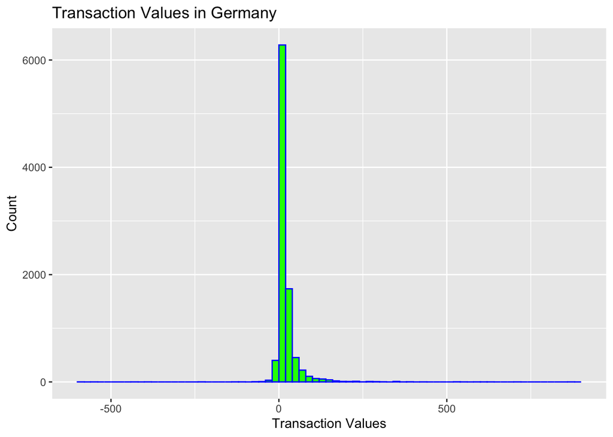

```r
ggplot(Germany_TransactionValue, aes(x=TransactionValue)) +
  geom_histogram(breaks=seq(-600,900,by=20),col="Blue",fill="Green")+
  labs(title="Transaction Values in Germany",x="Transaction Values",y="Count")
```

## 6. Which customer had the highest number of transactions? Which customer is most valuable (i.e. highest total sum of transactions)? (10 marks)

## 6.1 Which customer had the highest number of transactions

```r
# Customers id  with the  number of transactions each
Customer_TranNo <- Online_Retail%>%
  group_by(CustomerID)%>%
  summarise( TransactionNo= n())
#arranging data in descending format to find the customer with maximum no. of transactions
 arrange(Customer_TranNo,desc(TransactionNo))
```

```
## # A tibble: 4,373 x 2
##    CustomerID TransactionNo
##         <int>         <int>
##  1         NA        135080
##  2      17841          7983
##  3      14911          5903
##  4      14096          5128
##  5      12748          4642
##  6      14606          2782
##  7      15311          2491
##  8      14646          2085
##  9      13089          1857
## 10      13263          1677
## # … with 4,363 more rows
```

```r
#removing na values from the dataset( highest no. of transactions are coming for the Customer 'IDs as "NA")
Customer_TranNo<-na.omit(Customer_TranNo)

#Output:populating the customer with highest no. of transaction after removing NA customer ID's
top_n(Customer_TranNo,1)
```

```
## # A tibble: 1 x 2
##   CustomerID TransactionNo
##        <int>         <int>
## 1      17841          7983
```

## 6.2 Which customer is most valuable (i.e. highest total sum of transactions)?

```r
#Valuable Customer based on the highest total sum of transaction
Customer_TranVol <- Online_Retail%>%
  group_by(CustomerID)%>%
  summarise(sum_Transaction = sum(TransactionValue))
#arranging data in descending format to find the customer ID with  highest total sum of transactions
arrange(Customer_TranVol,desc(sum_Transaction))
```

```
## # A tibble: 4,373 x 2
##    CustomerID sum_Transaction
##         <int>           <dbl>
##  1         NA        1447682.
##  2      14646         279489.
##  3      18102         256438.
##  4      17450         187482.
##  5      14911         132573.
##  6      12415         123725.
##  7      14156         113384.
##  8      17511          88125.
##  9      16684          65892.
## 10      13694          62653.
## # … with 4,363 more rows
```

```r
#removing na values from the dataset(Since custmer id=NA  has the highest total sum of transactions)
Customer_TranVol<-na.omit(Customer_TranVol)

#Output:populating most valuable customer
top_n(Customer_TranVol,1)
```

```
## # A tibble: 1 x 2
##   CustomerID sum_Transaction
##        <int>           <dbl>
## 1      14646         279489.
```

## 7. Calculate the percentage of missing values for each variable in the dataset (5 marks). Hint colMeans():

```r
#Determining the Percentage of missing values for all the variables
colMeans(is.na(Online_Retail))
```

```
##         InvoiceNo         StockCode       Description          Quantity
##         0.0000000         0.0000000         0.0000000         0.0000000
##       InvoiceDate         UnitPrice        CustomerID           Country
##         0.0000000         0.0000000         0.2492669         0.0000000
##  TransactionValue  New_Invoice_Date  Invoice_Day_Week  New_Invoice_Hour
##         0.0000000         0.0000000         0.0000000         0.0000000
## New_Invoice_Month
##         0.0000000
```

## 8. What are the number of transactions with missing CustomerID records by countries? (10 marks)

```r
# Aggregating the date based on the countries and validating the customerID in terms of TRUE/FALSE by countries
 misCust <- Online_Retail%>%
  group_by(Country)%>%
  summarize(miss_val= is.na(CustomerID))
#Filtering the records based on missing values
mis_cust_cntry <- filter(misCust,miss_val=="TRUE")

#Output:Result for no. of transactions with missing CustomerID records by countries
count(mis_cust_cntry)
```

```
## # A tibble: 9 x 2
## # Groups:   Country [9]
##   Country             n
##   <chr>           <int>
## 1 Bahrain             2
## 2 EIRE              711
## 3 France             66
## 4 Hong Kong         288
## 5 Israel             47
## 6 Portugal           39
## 7 Switzerland       125
## 8 United Kingdom 133600
## 9 Unspecified       202
```

## 9. On average, how often the costumers comeback to the website for their next shopping? (i.e. what is the average number of days between consecutive shopping) (Optional/Golden question: 18 additional marks!) Hint: 1. A close approximation is also acceptable and you may find diff() function useful.

```r
#Creating subset with only required columns

Online_Retail_2<-subset(Online_Retail[,c(1,4,5,7,10)])
Online_Retail_2 <- na.omit(Online_Retail_2)

 #Aggregating the data based on Customer ID and determining the distinct InvoiceNo with the Invoice dates for all non-canceled transactions

InvoiceDt_byCustomerID <- Online_Retail_2 %>%
                         filter(Quantity>1) %>%
                         group_by(CustomerID) %>%
                         distinct(InvoiceNo,.keep_all = TRUE)%>%
                        arrange(CustomerID)

#Determining the difference of Invoice Dates
 Difference_InvoiceDt<-difftime(InvoiceDt_byCustomerID$New_Invoice_Date,lag(InvoiceDt_byCustomerID$New_Invoice_Date),units="days")


# Changing the type
Difference_InvoiceDt<-as.data.frame((Difference_InvoiceDt))

Difference_InvoiceDt$Dif_InvoiceDT<-Difference_InvoiceDt

#Merging the Invoice date difference  with  the data frame using cbind
 InvoiceDt_byCustomerID<-data.frame(cbind(InvoiceDt_byCustomerID,Difference_InvoiceDt$Dif_InvoiceDT))



 ## To determine the consumer's come back, we don't need the customer's with no recurring transactions.Therefore we should remove them in order to get the right result.

# Updating the first record of difference in dates for  each customer as NA , as it was difference of last transaction  of one customer id with first transaction date of another.Also, this will help to remove the records where customer didn't come for the second purchase.

 InvoiceDt_byCustomerID <- InvoiceDt_byCustomerID %>%
                          group_by(CustomerID) %>%
                          mutate(X.Difference_InvoiceDt. = replace ( X.Difference_InvoiceDt. , row_number(CustomerID) == 1, NA))

#Removing the NA values
InvoiceDt_byCustomerID<- na.omit(InvoiceDt_byCustomerID)

 #Output
 mean(InvoiceDt_byCustomerID$X.Difference_InvoiceDt.)
```

```
## Time difference of 40.44346 days
```

## 10. In the retail sector, it is very important to understand the return rate of the goods purchased by customers. In this example, we can define this quantity, simply, as the ratio of the number of transactions cancelled (regardless of the transaction value) over the total number of transactions. With this definition, what is the return rate for the French customers? (10 marks). Consider the cancelled transactions as those where the ‘Quantity’ variable has a negative value.

```r
#Filtering the records based on French customer with canceled transactions
France_cancelled<-filter(Online_Retail,Country=="France"&Quantity<0)


# Filtering the French Customer transactions
France_Total_Transactions<-filter(Online_Retail,Country=="France")


#Determining the rate of the canceled transactions by French Customer
rate<- (nrow(France_cancelled)/nrow(France_Total_Transactions))*100

#Output
print(rate)
```

```
## [1] 1.741264
```

## 11. What is the product that has generated the highest revenue for the retailer?(i.e. item with the highest total sum of ‘TransactionValue’). (10 marks)

```r
#Aggregating the Transaction Value based on Product
high_Revenue_Product <- Online_Retail%>%
  group_by(Online_Retail$Description)%>%
  summarise(highRev = sum(TransactionValue))
# Output:To determine the product with highest revenue
top_n(high_Revenue_Product,1)
```

```
## # A tibble: 1 x 2
##   `Online_Retail$Description` highRev
##   <chr>                         <dbl>
## 1 DOTCOM POSTAGE              206245.
```

## 12. How many unique customers are represented in the dataset? You can use unique() and length() functions. (5 marks)

```r
#Storing the unique customer ids in a new data frame
unique_customers<-data.frame(unique(Online_Retail$CustomerID,incomparables =FALSE,nmax=NA))

# Output:To check the count of unique customers
count(unique_customers)
```

```
##      n
## 1 4373
```